# Exam 2

Steve Harms

April 15, 2019

# Data Collection and Cleaning

### I will use the NBA data. We can collect data on both team wins and losses, as well as individual player statistics. I will primarily use player statistics in my analysis. I use data from 2010-2019, which I can gather by first writing a few functions. In addition to player information including Name, Position, Age, Team, and Year, I collect several other variables. We can include shooting stats like 3pt Attempts and %, 2pt attempts and %, and FT attempts and %. We can discard the number of shots made, because those variables can be calculated from the above directly. We also have other stats like rebounding (offensive and defensive), assists, steals, blocks, turnovers and personal fouls. Finally, we can include overall measures of player ability and importance like PER (player efficiency rating), Win Shares, Value over replacement player, and Usage rate, which are aggregates of other stats and attempt to evaluate a player’s overall effectiveness.

```r
#Functions to scrape data from basketball-reference.com

get_nba_standings<-function(year){
urlt <- paste0('https://www.basketball-reference.com/leagues/NBA_',year,'_standings.html')
nbat <- read_html(urlt) %>% html_table() %>% lapply(data.frame)
colnames(nbat[[2]]) = colnames(nbat[[1]])
nbateams <- data.frame(rbind(nbat[[1]],nbat[[2]])) %>% as_tibble()
colnames(nbateams) <- c('Team', colnames(nbat[[1]])[-1])
nbateams <- nbateams %>%
  select(-GB) %>% type_convert %>%
  mutate(Team = str_sub(as.character(Team),end=str_locate(as.character(Team),'\\*?\\s*\\([:digit:]+\\)')[,1]-1)) %>%
  mutate(Team=as.factor(Team)) %>%
  mutate(year=as.factor(year)) %>% select(1,8,2:7)
return(nbateams)
}
#####################
#####################
get_player_stats <- function(year){
#basic stats
urlb <- paste0('https://www.basketball-reference.com/leagues/NBA_',year,'_totals.html')
nbaplayers <- read_html(urlb) %>% html_table() %>% data.frame() %>%
  filter(PF != 'PF', Tm!='TOT') %>% as_tibble() %>% type_convert()

#advanced statistics
urla <- paste0('https://www.basketball-reference.com/leagues/NBA_',year,'_advanced.html')
nbaadv <- read_html(urla) %>% html_table() %>% data.frame() %>%
  filter(Pos != 'Pos', Tm!='TOT')  %>% as_tibble() %>% type_convert()

#variables to use for analysis
playerdata <- nbaplayers %>% select(-c(1,9:11,12,15,18,19,24,30)) %>% full_join(nbaadv %>% select(2:5,8,19,24,29)) %>%
  mutate_at(c(1,2,4), as_factor) %>% mutate(year = as.factor(year)) %>% select(1:4,25,5:24)
return(playerdata)
}

######################################
#collect data

years<- c(2010:2019)
#W-L for each team
teamdata <- suppressWarnings(suppressMessages(
  years %>% lapply(get_nba_standings) %>% lapply(filter, !is.na(Team))%>% lapply(type_convert) %>%
  bind_rows %>% as_tibble() %>% type_convert %>% mutate(year=as.factor(year))
))

#team abbreviations
nodes <- read_html('https://www.basketball-reference.com/leagues/NBA_2019_standings.html') %>% html_nodes('body') %>% html_children() %>% html_nodes('a') %>%
  html_attr('href')
acros <- nodes %>% str_sub(start=str_locate(nodes,'\\/teams\\/')[,2]+1,end=str_locate(nodes,paste0('\\/',2019))[,1]-1) %>% unique()
nbateams <- get_nba_standings(2019) %>% mutate(abbr = as.factor(acros[-1]))  %>% type_convert %>% select(Team,abbr)
```

```
## cols()
```

```r
nbateams
```

```
## # A tibble: 30 x 2
##    Team               abbr
##    <fct>              <fct>
##  1 Milwaukee Bucks    MIL
##  2 Toronto Raptors    TOR
##  3 Philadelphia 76ers PHI
##  4 Boston Celtics     BOS
##  5 Indiana Pacers     IND
##  6 Brooklyn Nets      BRK
##  7 Orlando Magic      ORL
##  8 Detroit Pistons    DET
##  9 Charlotte Hornets  CHO
## 10 Miami Heat         MIA
## # ... with 20 more rows
```

```r
nbateamdata <- teamdata %>% left_join(nbateams, by=c('Team'='Team')) %>%
  mutate(abbr=as.character(abbr)) %>% select(1,9,2:8)
nbateamdata$abbr[which(nbateamdata$Team=='New Jersey Nets')] <- 'NJN'
nbateamdata
```

```
## # A tibble: 300 x 9
##    Team                abbr  year      W     L  W.L.  PS.G  PA.G   SRS
##    <chr>               <chr> <fct> <dbl> <dbl> <dbl> <dbl> <dbl> <dbl>
##  1 Boston Celtics      BOS   2010     50    32 0.61   99.2  95.6  3.37
##  2 Toronto Raptors     TOR   2010     40    42 0.488 104.  106.  -1.83
##  3 New York Knicks     NYK   2010     29    53 0.354 102.  106.  -4.01
##  4 Philadelphia 76ers  PHI   2010     27    55 0.329  97.7 102.  -3.93
##  5 New Jersey Nets     NJN   2010     12    70 0.146  92.4 102.  -8.93
##  6 Cleveland Cavaliers CLE   2010     61    21 0.744 102.   95.6  6.17
##  7 Milwaukee Bucks     MIL   2010     46    36 0.561  97.7  96    1.37
##  8 Chicago Bulls       CHI   2010     41    41 0.5    97.5  99.1 -1.64
##  9 Indiana Pacers      IND   2010     32    50 0.39  101.  104.  -3.11
## 10 Detroit Pistons     DET   2010     27    55 0.329  94    99.1 -5.02
## # ... with 290 more rows
```

```r
#Player statistics for each year
playerdata <- suppressWarnings(suppressMessages(
  years %>% lapply(get_player_stats) %>% lapply(type_convert) %>%
    bind_rows %>% as_tibble() %>% type_convert %>%
    mutate(year=as.factor(year)) %>%
    mutate(FT.=100*FT., X2P.=100*X2P., X3P.=100*X3P.)
  ))

#complete cases only
playerdata <- playerdata %>% filter(complete.cases(.))
#we might also want to adjust for amount of time (in minutes) each player has played
player_perminute <- playerdata %>% mutate_at(c(9,11,13,15:21), funs(./playerdata$MP)) %>%
  filter(complete.cases(.))

#write the data to csv
#not run
#write_csv(nbateamdata, "nbateamdata.csv")
#write_csv(playerdata, "nbaplayerdata.csv")
```

# Data Visualization

### We can explore some of the properties of the player statistics by looking at each variable individually as well as the multivariate relationships:

## Univariate histograms

#### We can identify possible cases where normality is violated by looking at each univariate histogram. The variables have heavily skewed distributions in the unadjusted case, however when we adjust by minutes played the distributions look much more approximately normal:

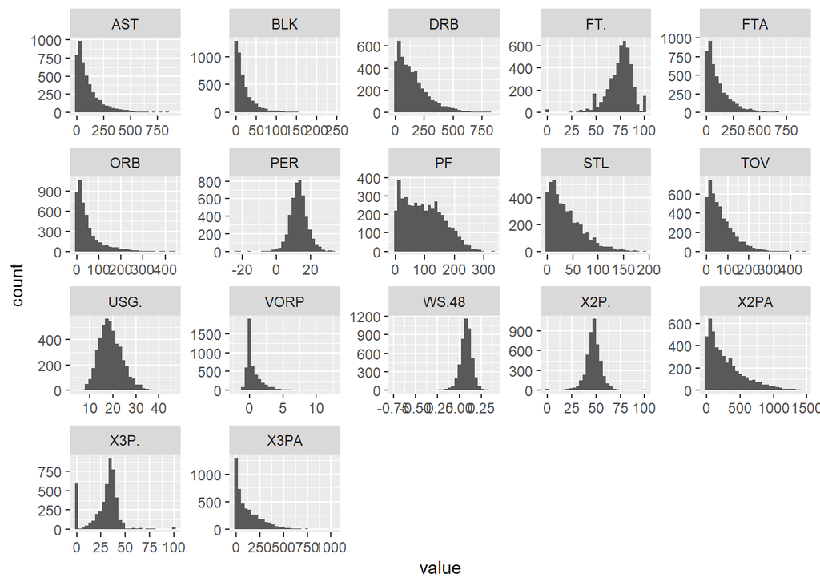

```r
#raw data
ggplot(data=(playerdata %>% gather(key=stat, value=value, -c(1:8)))) +
  geom_histogram(aes(x=value)) +
  facet_wrap(.~stat, scales="free")
```

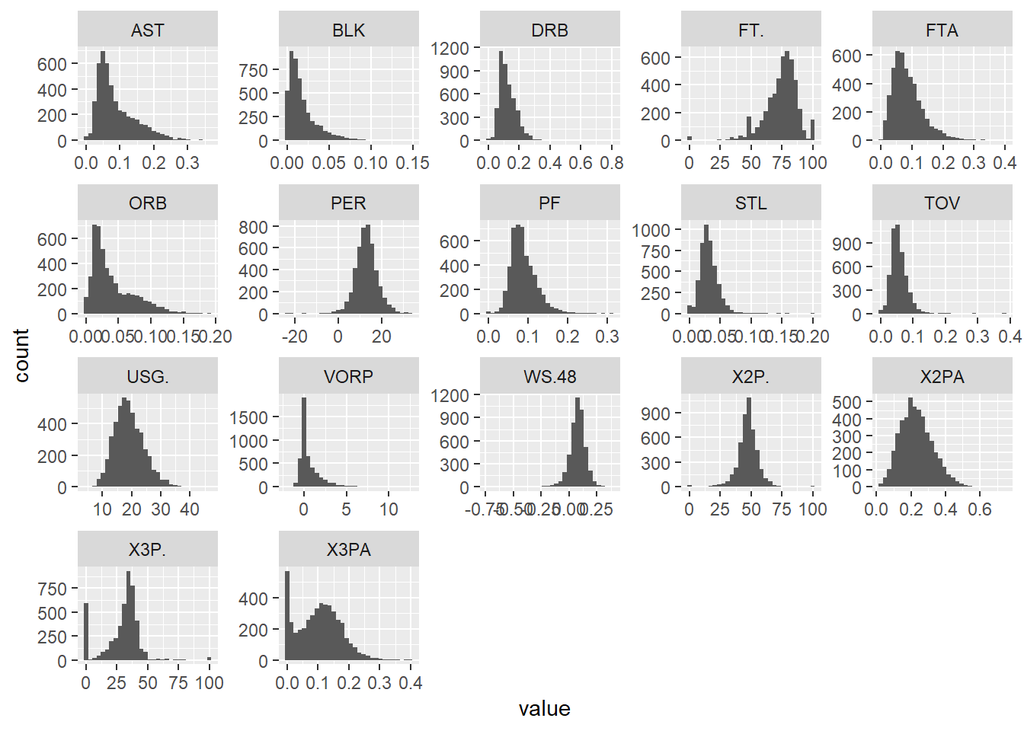

```r
#per minute data looks more normal
ggplot(data=(player_perminute %>% gather(key=stat, value=value, -c(1:8)))) +
  geom_histogram(aes(x=value)) +
  facet_wrap(.~stat, scales="free")
```

## Pairwise correlations

#### We can look at relationships between variables by looking at the pairwise scatterplots, using from the GGally package.

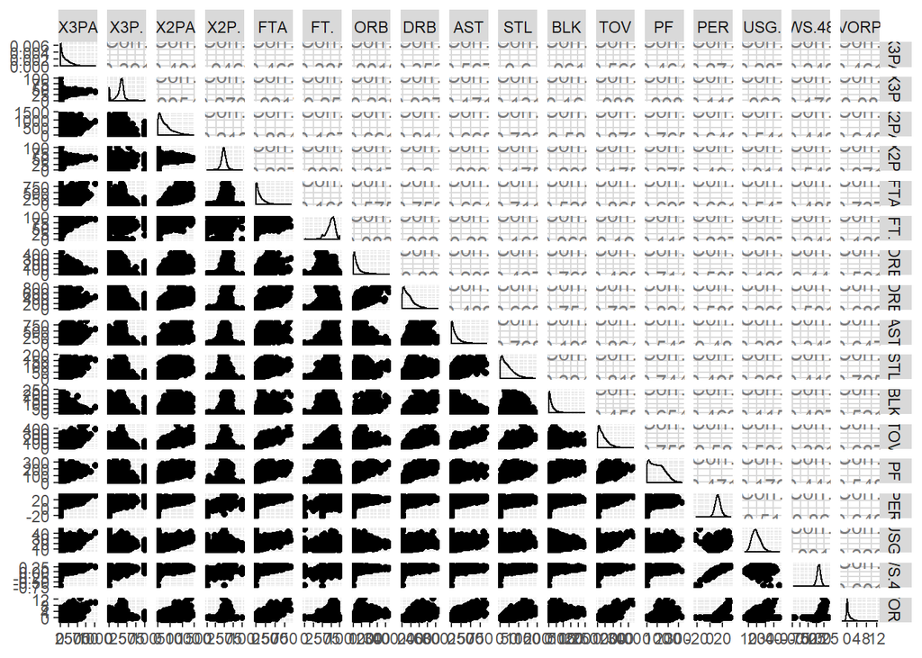

```r
ggpairs(playerdata[,9:25])
```

## Correlation Matrix

#### The correlation matrices, both adjusted and not, show some interesting positive correlations between # of shots attempted (2,3,and FT) and the “overall aggregate” stats like VORP, WS, USG, and PER. There is also negative correlations between 3P attempts vs. 2P attempts, as well as assists vs. ORB/DRB, which are indicators that there will be a difference between guards who pass and take long shots vs. forwards/centers who take closer shots and collect rebounds. These are also reflected in the pairwise correlation plot.

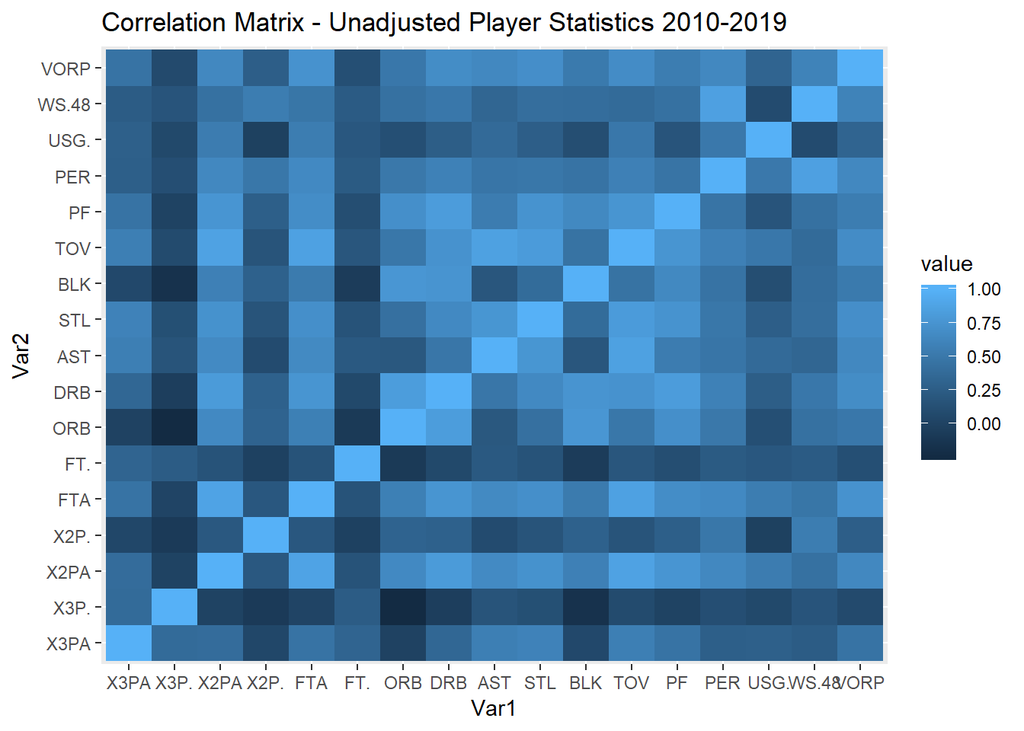

```r
covp <- playerdata %>% select(9:25) %>% var(na.rm=TRUE)
corp <- playerdata %>% select(9:25) %>% cor(use="complete.obs")
covpm <- player_perminute %>% select(9:25) %>% var(na.rm=TRUE)
corpm <- player_perminute %>% select(9:25) %>% cor(use="complete.obs")

ggplot(data = corp %>% melt, aes(x=Var1, y=Var2, fill=value)) +
  geom_tile() + ggtitle("Correlation Matrix - Unadjusted Player Statistics 2010-2019")
```

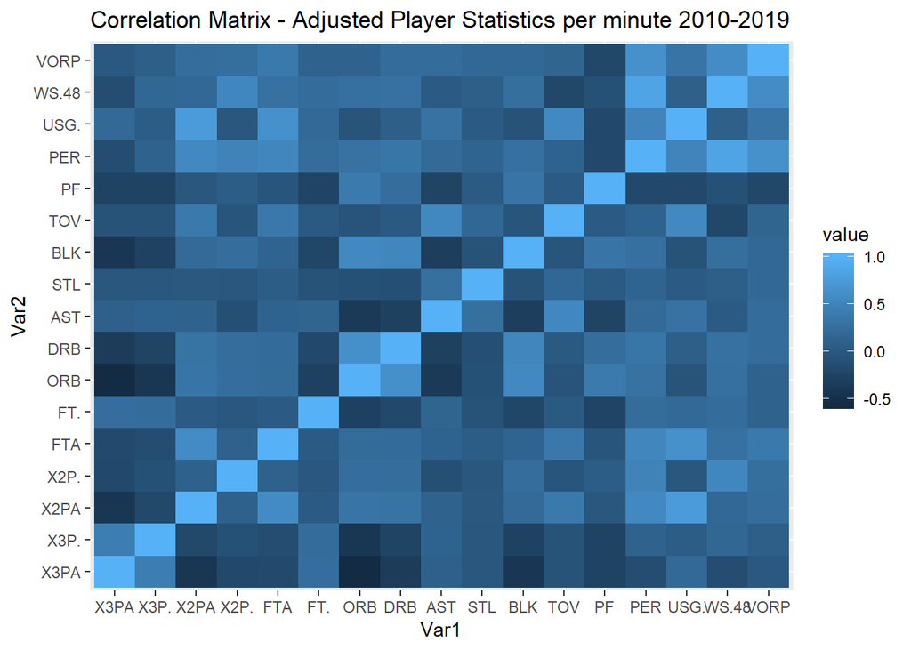

```r
ggplot(data = corpm %>% melt, aes(x=Var1, y=Var2, fill=value)) +
  geom_tile() + ggtitle("Correlation Matrix - Adjusted Player Statistics per minute 2010-2019")
```

## QQplot

#### Individual normal quantile plots indicate that very few of our variables are normally distributed marginally. The chi-squared plot shows similar results for multivariate normality. However, our sample size is large so we don’t need to worry too much about this.

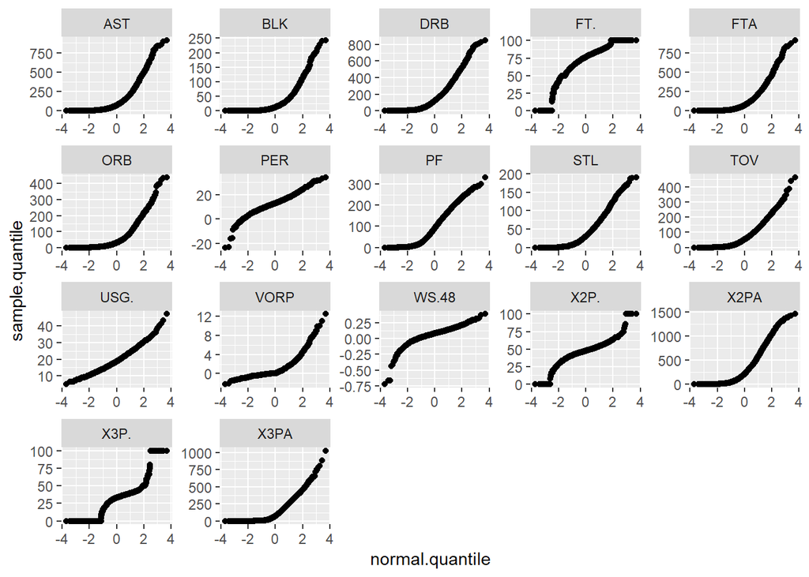

```r
#QQplots
QQplot.normal = function(x){
  # x is an observed vector of a variable
  x.sort = sort(x)
  n = length(x)
  p = ( c(1 : n) - 0.5 ) / n
  q = qnorm(p)
  res = data.frame(cbind(x.sort, q))
  names(res) = c("sample.quantile", "normal.quantile")
  return(res)
}

QQs <- apply(playerdata[,-c(1:8)] %>% filter(complete.cases(.)),2,FUN=QQplot.normal) %>% as.data.frame()
QQs <- data.frame(sample.quantile = gather(QQs[,seq(from=1, to=33, by=2)])[,2],
                  normal.quantile=gather(QQs[,seq(from=2, to=34, by=2)])[,2],
                  var= rep(names(player_perminute)[9:25], each=nrow(QQs)))
ggplot(data = QQs) + geom_point(aes(x=normal.quantile, y=sample.quantile)) +
  facet_wrap(.~var, scales='free')
```

## Group Mean Plots by Position and Year

#### We can look for possible differences between the five positions and the ten years to inform a MANOVA or multiple regression analysis. We can see from the plots that there is clearly some differences between the PG means (in purple) and the PF and C positions (green and gold) in every year. However, we can see that in more recent years (2018-19) those differences are not as obvious as in 2010-11. This provides evidence that position classifications are not as important in the modern NBA game.

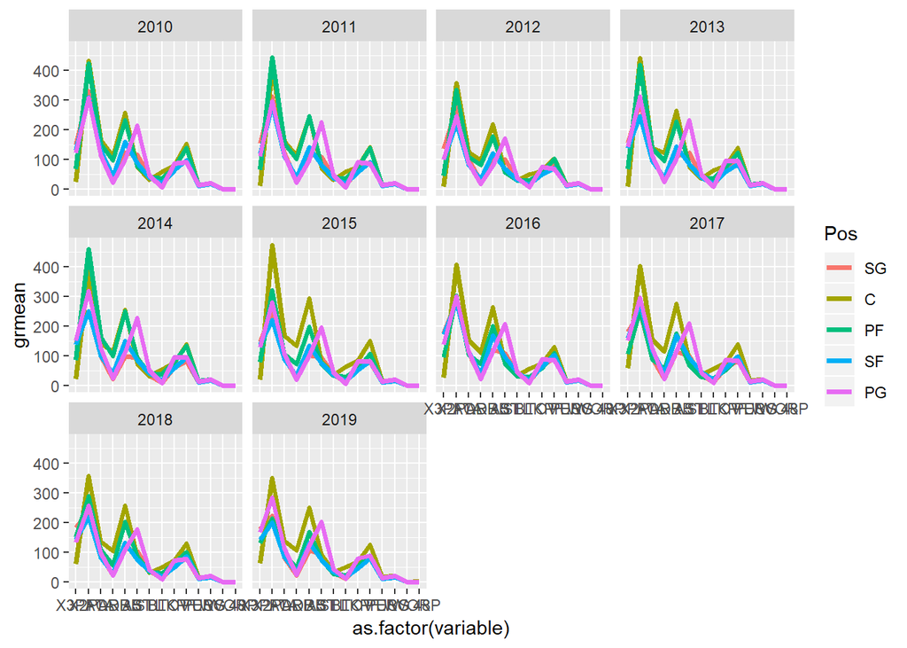

```r
#Plotting variable means by position
summed <- playerdata %>%
  select(-Player,-Tm,-Age,-G,-GS, -MP,-FT.,-X2P.,-X3P.) %>%
  melt(id=c('Pos','year')) %>%
  group_by(Pos,year,variable) %>% summarise(grmean=mean(value))
ggplot(data=(summed)) + geom_line(aes(x=as.factor(variable), group=Pos, y=grmean, color=Pos), size=1.3) +
  facet_wrap(.~year)
```

# MANOVA

#### From our last plots, we want to investigate whether position, team, and/or year have an effect on the group means of our 17 different stats. The first output shows that, for any choice of test statistic, we have statistically significant evidence that Position is an important factor in the group means for our player statistics.

#### The second and third outputs from MANOVA analyses show that in addition to Position, “Year” and “Team” as well as the interactions between Year/Pos and Team/Pos are non-zero. This indicates that the group means for each position are different across years and teams. It should be noted that the p-value for the interaction between year and position is somewhat large for this sample size, indicating that our results are not too conclusive.

```r
#MANOVA
#fit linear model with Position as the factor
fitlm <- lm(as.matrix(playerdata[,9:25])~playerdata$Pos)
manova.pos <- Manova(fitlm)
summary(manova.pos)
```

```
##
## Type II MANOVA Tests:
##
## Sum of squares and products for error:
##              X3PA        X3P.         X2PA        X2P.          FTA
## X3PA  72350922.39 2594793.083  76820906.42  682050.644  37730541.12
## X3P.   2594793.08  894529.807   1168982.55    7107.425    520137.27
## X2PA  76820906.42 1168982.554 349397364.71 1893194.466 138763949.41
## X2P.    682050.64    7107.425   1893194.47  311937.534    874889.05
## FTA   37730541.12  520137.269 138763949.41  874889.046  70613824.68
## FT.    2236194.54  175967.613   3490473.92   29580.967   1478000.29
## ORB    5705977.90 -205245.365  41311275.88  342698.552  16545438.99
## DRB   39366693.28  821253.384 134630719.21 1022262.337  57208318.01
## AST   41152674.24 1054359.712 113109609.84  836885.598  49659121.82
## STL   11570031.68  235478.195  31594573.59  264971.377  13582246.18
## BLK    3838455.99   13926.509  18720372.79  169862.330   7896163.81
## TOV   21242634.21  407906.459  67151662.57  435650.807  29741808.54
## PF    21995731.21  437314.318  61890635.94  528448.777  25301997.80
## PER    1128114.10   74719.536   3908547.68   85183.764   1831003.76
## USG.    844462.03   18369.984   3496425.81    2174.720   1581396.83
## WS.48    15205.92    1364.153     38182.54    1387.510     19438.27
## VORP    399616.41   10925.770   1060377.88   12290.431    544044.80
##               FT.          ORB          DRB          AST          STL
## X3PA  2236194.545  5705977.903  39366693.28  41152674.24 11570031.678
## X3P.   175967.613  -205245.365    821253.38   1054359.71   235478.195
## X2PA  3490473.917 41311275.882 134630719.21 113109609.84 31594573.593
## X2P.    29580.967   342698.552   1022262.34    836885.60   264971.377
## FTA   1478000.287 16545438.992  57208318.01  49659121.82 13582246.185
## FT.    842776.444   118362.960   1286107.88   1305194.40   297626.572
## ORB    118362.960  9881409.020  21841309.09  10969752.21  4163105.084
## DRB   1286107.885 21841309.091  74849404.36  47720465.15 14679169.698
## AST   1305194.401 10969752.208  47720465.15  64751468.51 14190103.389
## STL    297626.572  4163105.084  14679169.70  14190103.39  4929207.201
## BLK     87433.914  3584666.654  10288010.83   5309723.37  1947851.672
## TOV    694681.338  7811222.870  28674958.87  28944780.08  7397641.232
## PF     700589.365  9726504.346  30703555.71  23321835.76  7737288.788
## PER     92726.471   466067.675   1588757.19   1493195.81   395137.111
## USG.    59158.180   209946.336    954740.23    964037.80   196100.363
## WS.48    1415.034     5455.714     18705.79     17386.93     4961.839
## VORP    12681.658   146814.223    538194.08    510207.45   141614.629
```

[output cut: 108 more lines]

```
## TOV      90.919534   3010.64719
## PF     1681.397187  13067.83981
## PER     137.203695   1184.18624
## USG.    -26.515390   -131.25432
## WS.48     2.020859     16.17897
## VORP     16.178971    147.61743
##
## Multivariate Tests: playerdata$Pos
##                  Df test stat approx F num Df   den Df     Pr(>F)
## Pillai            4 0.9671911  86.2744     68 18396.00 < 2.22e-16 ***
## Wilks             4 0.2659119 106.5034     68 18038.32 < 2.22e-16 ***
## Hotelling-Lawley  4 1.9319027 130.5313     68 18378.00 < 2.22e-16 ***
## Roy               4 1.3952637 377.4599     17  4599.00 < 2.22e-16 ***
## ---
## Signif. codes:  0 '***' 0.001 '**' 0.01 '*' 0.05 '.' 0.1 ' ' 1
```

```r
fitlmtwo <- lm(as.matrix(playerdata[,9:25])~playerdata$Pos * playerdata$Tm)
manova.team <- Manova(fitlmtwo)
summary(manova.team)
```

```
##
## Type II MANOVA Tests:
##
## Sum of squares and products for error:
##              X3PA        X3P.         X2PA        X2P.          FTA
## X3PA  68399864.68 2423804.162  75649292.97  631604.637  36414268.15
## X3P.   2423804.16  842573.304   1329807.05    6557.049    582502.38
## X2PA  75649292.97 1329807.052 329119662.51 1873839.813 130577478.84
## X2P.    631604.64    6557.049   1873839.81  292341.132    858345.64
## FTA   36414268.15  582502.379 130577478.84  858345.643  65870227.40
## FT.    2090985.37  164087.133   3186595.31   32566.367   1349833.25
## ORB    6015186.58 -125855.334  38928261.18  320133.723  15607730.15
## DRB   38311115.85  865820.909 127594909.96  963168.512  53918252.35
## AST   39960042.63 1037665.695 108583883.02  806138.643  47510193.88
## STL   11303146.94  242218.217  30411404.94  247028.712  13016663.66
## BLK    3723920.18   20055.459  17762626.70  158517.449   7467297.73
## TOV   20632241.38  431387.528  63821686.01  421908.961  28147966.25
## PF    21576473.10  448712.980  59599731.21  495578.965  24395087.61
## PER    1084004.32   73622.667   3693367.68   80780.221   1720886.16
## USG.    800794.21   20806.852   3226474.96    4117.626   1443961.88
## WS.48    14310.69    1289.050     36385.21    1286.369     18420.36
## VORP    377152.01   10670.363   1009250.95   11283.485    511532.75
##               FT.          ORB          DRB          AST          STL
## X3PA  2090985.373  6015186.580  38311115.85  39960042.63 11303146.939
## X3P.   164087.133  -125855.334    865820.91   1037665.69   242218.217
## X2PA  3186595.305 38928261.183 127594909.96 108583883.02 30411404.944
## X2P.    32566.367   320133.723    963168.51    806138.64   247028.712
## FTA   1349833.245 15607730.147  53918252.35  47510193.88 13016663.656
## FT.    793286.971   154982.379   1245045.05   1203588.99   293827.696
## ORB    154982.379  8880773.525  20337629.42  10643709.79  3913697.768
## DRB   1245045.048 20337629.422  70108775.22  45562124.97 13964897.021
## AST   1203588.986 10643709.793  45562124.97  61722857.87 13675202.599
## STL    293827.696  3913697.768  13964897.02  13675202.60  4696478.223
## BLK     87389.555  3373053.521   9693127.53   5084336.68  1865486.072
## TOV    650622.363  7391693.439  27217155.22  27674980.69  7099859.283
## PF     684929.471  9160409.858  29383130.88  22626676.43  7439567.237
## PER     86041.785   442318.831   1495823.88   1425773.33   377181.086
## USG.    51223.024   208851.468    899800.68    908867.59   190018.118
## WS.48    1329.795     5192.525     17477.04     16528.69     4670.408
## VORP    11451.460   139180.299    503980.83    482539.70   133886.931
```

[output cut: 282 more lines]

```
## TOV    189.7424720 10340.39585
## PF     170.3642312  4344.21238
## PER     43.7921184   889.67476
## USG.    12.2055806   853.04986
## WS.48    0.6747198     8.18631
## VORP     8.1863096   412.28965
##
## Multivariate Tests: playerdata$Pos:playerdata$Tm
##                   Df test stat approx F num Df   den Df     Pr(>F)
## Pillai           128 1.0638841 2.321972   2176 75684.00 < 2.22e-16 ***
## Wilks            128 0.3281707 2.351662   2176 74876.42 < 2.22e-16 ***
## Hotelling-Lawley 128 1.1687674 2.381642   2176 75380.00 < 2.22e-16 ***
## Roy              128 0.2012519 6.999794    128  4452.00 < 2.22e-16 ***
## ---
## Signif. codes:  0 '***' 0.001 '**' 0.01 '*' 0.05 '.' 0.1 ' ' 1
```

```r
fitlmthree <- lm(as.matrix(playerdata[,9:25])~playerdata$Pos*as.factor(playerdata$year))
manova.year <- Manova(fitlmthree)
summary(manova.year)
```

```
##
## Type II MANOVA Tests:
##
## Sum of squares and products for error:
##              X3PA        X3P.         X2PA        X2P.          FTA
## X3PA  70156930.61 2408436.884  78600124.48  579946.409  38023697.54
## X3P.   2408436.88  863362.631   1487268.32   -2394.646    601256.60
## X2PA  78600124.48 1487268.323 339957540.91 1996503.405 135540428.07
## X2P.    579946.41   -2394.646   1996503.41  301499.749    895097.24
## FTA   38023697.54  601256.603 135540428.07  895097.244  69322440.62
## FT.    2160524.68  167251.502   3504547.24   25362.969   1467842.34
## ORB    6144821.15 -133865.680  39519540.17  361909.662  15983485.64
## DRB   39172418.90  870019.366 131872720.29 1010362.139  56169233.45
## AST   40754593.40 1031729.028 111953064.95  826833.966  49127585.09
## STL   11560442.46  245422.914  30956889.97  268573.605  13347060.01
## BLK    3939903.89   36213.650  18157594.80  176483.083   7720917.99
## TOV   21323148.55  435133.954  65873866.64  448619.409  29264551.71
## PF    22117911.94  493153.199  59880238.62  536567.542  24560511.39
## PER    1131655.09   74561.464   3854797.36   84171.504   1810745.96
## USG.    860981.23   19506.288   3450809.72    2920.864   1564220.16
## WS.48    15115.27    1350.940     37555.64    1365.462     19180.73
## VORP    400343.29   11164.009   1041887.11   12329.541    536558.40
##              FT.          ORB          DRB          AST          STL
## X3PA  2160524.68  6144821.151  39172418.90  40754593.40 11560442.462
## X3P.   167251.50  -133865.680    870019.37   1031729.03   245422.914
## X2PA  3504547.24 39519540.173 131872720.29 111953064.95 30956889.967
## X2P.    25362.97   361909.662   1010362.14    826833.97   268573.605
## FTA   1467842.34 15983485.640  56169233.45  49127585.09 13347060.011
## FT.    832511.15   124172.829   1254887.22   1285185.60   290993.245
## ORB    124172.83  9469091.769  21270298.45  10845513.24  4057197.910
## DRB   1254887.22 21270298.453  73573660.68  47282416.67 14457279.454
## AST   1285185.60 10845513.236  47282416.67  64103593.25 14027253.140
## STL    290993.24  4057197.910  14457279.45  14027253.14  4859050.071
## BLK     90657.42  3462301.617  10094212.83   5277615.07  1915133.675
## TOV    689658.82  7599310.743  28279693.15  28656629.23  7286269.340
## PF     700033.70  9338658.627  29995340.14  22987465.90  7581006.715
## PER     91187.25   455249.879   1567682.41   1483397.62   390513.270
## USG.    59140.57   201588.441    943925.75    959880.92   193512.534
## WS.48    1387.48     5330.646     18405.44     17241.84     4897.175
## VORP    12448.43   143535.096    531811.77    505946.23   139918.703
```

[output cut: 282 more lines]

```
## TOV    85.9693614 1500.735572
## PF    119.9909480 1939.007536
## PER    25.1938640  273.809606
## USG.    6.5835471  119.304604
## WS.48   0.3867599    3.904985
## VORP    3.9049851   60.408252
##
## Multivariate Tests: playerdata$Pos:as.factor(playerdata$year)
##                  Df test stat approx F num Df   den Df     Pr(>F)
## Pillai           36 0.1815393 1.369345    612 77639.00 3.4670e-09 ***
## Wilks            36 0.8318372 1.378946    612 70149.15 1.5627e-09 ***
## Hotelling-Lawley 36 0.1867776 1.388355    612 77335.00 6.8069e-10 ***
## Roy              36 0.0607808 7.710726     36  4567.00 < 2.22e-16 ***
## ---
## Signif. codes:  0 '***' 0.001 '**' 0.01 '*' 0.05 '.' 0.1 ' ' 1
```

# Multivariate Multiple Linear Regression

#### We can do a similar analysis as the MANOVA, except with multiple linear regression. I use minutes played and age in addition to the the factors use above as predictors in the analysis. I start with the most simple MLR model with no interactions, which shows that the coefficients are significantly non-zero. Then I add in year and team as predictors, however the resulting model has coefficients that are not significant at a 5% level. Finally, I fit a third model with interaction between player and team, as in the MANOVA analysis above. Many of these terms are non-zero. However, assessing the fit of these three models with a Likelihood Ratio Test indicates that this third model fits the data best (likely due to large sample size and overfitting).

```r
mlrfit.y <- lm(as.matrix(playerdata[,9:25])~playerdata$MP+ playerdata$Age + playerdata$Pos)
summary(mlrfit.y)
```

```
## Response X3PA :
##
## Call:
## lm(formula = X3PA ~ playerdata$MP + playerdata$Age + playerdata$Pos)
##
## Residuals:
##     Min      1Q  Median      3Q     Max
## -283.95  -41.86   -7.12   42.03  707.43
##
## Coefficients:
##                    Estimate Std. Error t value Pr(>|t|)
## (Intercept)      -9.199e+00  8.670e+00  -1.061    0.289
## playerdata$MP     1.053e-01  1.552e-03  67.820  < 2e-16 ***
## playerdata$Age    1.863e+00  3.087e-01   6.034 1.73e-09 ***
## playerdata$PosC  -1.414e+02  4.437e+00 -31.880  < 2e-16 ***
## playerdata$PosPF -7.450e+01  3.969e+00 -18.769  < 2e-16 ***
## playerdata$PosSF -2.526e+01  3.900e+00  -6.478 1.03e-10 ***
## playerdata$PosPG -2.603e+01  3.812e+00  -6.829 9.67e-12 ***
## ---
## Signif. codes:  0 '***' 0.001 '**' 0.01 '*' 0.05 '.' 0.1 ' ' 1
##
## Residual standard error: 88.37 on 4610 degrees of freedom
## Multiple R-squared:  0.5503, Adjusted R-squared:  0.5498
## F-statistic: 940.4 on 6 and 4610 DF,  p-value: < 2.2e-16
##
##
## Response X3P. :
##
## Call:
## lm(formula = X3P. ~ playerdata$MP + playerdata$Age + playerdata$Pos)
##
## Residuals:
##     Min      1Q  Median      3Q     Max
## -34.696  -5.475   1.207   6.641  84.960
##
## Coefficients:
##                    Estimate Std. Error t value Pr(>|t|)
## (Intercept)       2.283e+01  1.345e+00  16.973  < 2e-16 ***
## playerdata$MP     2.593e-03  2.407e-04  10.770  < 2e-16 ***
## playerdata$Age    2.747e-01  4.789e-02   5.736 1.03e-08 ***
```

[output cut: 385 more lines]

```
## Coefficients:
##                    Estimate Std. Error t value Pr(>|t|)
## (Intercept)      -1.193e+00  9.519e-02 -12.532  < 2e-16 ***
## playerdata$MP     1.025e-03  1.704e-05  60.131  < 2e-16 ***
## playerdata$Age    1.543e-02  3.389e-03   4.552 5.46e-06 ***
## playerdata$PosC   4.680e-01  4.871e-02   9.609  < 2e-16 ***
## playerdata$PosPF  2.045e-01  4.357e-02   4.694 2.76e-06 ***
## playerdata$PosSF  1.622e-01  4.282e-02   3.788 0.000154 ***
## playerdata$PosPG  2.012e-01  4.185e-02   4.808 1.57e-06 ***
## ---
## Signif. codes:  0 '***' 0.001 '**' 0.01 '*' 0.05 '.' 0.1 ' ' 1
##
## Residual standard error: 0.9701 on 4610 degrees of freedom
## Multiple R-squared:  0.4523, Adjusted R-squared:  0.4516
## F-statistic: 634.4 on 6 and 4610 DF,  p-value: < 2.2e-16
```

```r
mlrfit.r <- lm(as.matrix(playerdata[,9:25])~playerdata$MP+ playerdata$Age + as.factor(playerdata$year) +playerdata$Pos + playerdata$Tm)
#summary(mlrfit.r)

mlrfit <- lm(as.matrix(playerdata[,9:25])~playerdata$MP+ playerdata$Age + as.factor(playerdata$year) +
               playerdata$Pos + playerdata$Tm + playerdata$Pos * playerdata$Tm)
#Likelihood Ratio Test
anova(mlrfit,mlrfit.r, mlrfit.y)
```

```
## Analysis of Variance Table
##
## Model 1: as.matrix(playerdata[, 9:25]) ~ playerdata$MP + playerdata$Age +
##     as.factor(playerdata$year) + playerdata$Pos + playerdata$Tm +
##     playerdata$Pos * playerdata$Tm
## Model 2: as.matrix(playerdata[, 9:25]) ~ playerdata$MP + playerdata$Age +
##     as.factor(playerdata$year) + playerdata$Pos + playerdata$Tm
## Model 3: as.matrix(playerdata[, 9:25]) ~ playerdata$MP + playerdata$Age +
##     playerdata$Pos
##   Res.Df  Df Gen.var.  Pillai approx F num Df den Df    Pr(>F)
## 1   4441       112.44
## 2   4569 128   117.05 1.11144   2.4270   2176  75497 < 2.2e-16 ***
## 3   4610  41   121.81 0.78862   5.2692    697  75497 < 2.2e-16 ***
## ---
## Signif. codes:  0 '***' 0.001 '**' 0.01 '*' 0.05 '.' 0.1 ' ' 1
```

```r
summary(mlrfit)
```

```
## Response X3PA :
##
## Call:
## lm(formula = X3PA ~ playerdata$MP + playerdata$Age + as.factor(playerdata$year) +
##     playerdata$Pos + playerdata$Tm + playerdata$Pos * playerdata$Tm)
##
## Residuals:
##     Min      1Q  Median      3Q     Max
## -343.59  -45.76   -2.70   42.54  608.47
##
## Coefficients:
##                                     Estimate Std. Error t value Pr(>|t|)
## (Intercept)                       -2.887e+01  1.625e+01  -1.777 0.075652
## playerdata$MP                      1.082e-01  1.487e-03  72.749  < 2e-16
## playerdata$Age                     1.952e+00  3.021e-01   6.461 1.15e-10
## as.factor(playerdata$year)2011    -1.308e+00  5.717e+00  -0.229 0.819049
## as.factor(playerdata$year)2012     7.303e+00  5.796e+00   1.260 0.207724
## as.factor(playerdata$year)2013     1.149e+01  5.731e+00   2.005 0.045036
## as.factor(playerdata$year)2014     1.712e+01  5.715e+00   2.996 0.002753
## as.factor(playerdata$year)2015     2.278e+01  5.647e+00   4.034 5.58e-05
## as.factor(playerdata$year)2016     3.378e+01  5.692e+00   5.935 3.17e-09
## as.factor(playerdata$year)2017     4.726e+01  5.638e+00   8.383  < 2e-16
## as.factor(playerdata$year)2018     5.608e+01  5.565e+00  10.078  < 2e-16
## as.factor(playerdata$year)2019     6.891e+01  5.489e+00  12.555  < 2e-16
## playerdata$PosC                   -1.255e+02  2.104e+01  -5.964 2.64e-09
## playerdata$PosPF                  -9.178e+01  2.018e+01  -4.547 5.58e-06
## playerdata$PosSF                  -3.613e+01  1.951e+01  -1.851 0.064166
## playerdata$PosPG                  -3.654e+01  2.019e+01  -1.810 0.070342
## playerdata$TmBOS                  -2.628e+01  1.951e+01  -1.347 0.178085
## playerdata$TmBRK                  -4.074e+00  2.059e+01  -0.198 0.843198
## playerdata$TmCHA                  -5.482e+01  2.370e+01  -2.314 0.020740
## playerdata$TmCHI                  -4.327e+01  1.884e+01  -2.297 0.021672
## playerdata$TmCHO                  -2.857e+01  2.187e+01  -1.306 0.191491
## playerdata$TmCLE                  -1.906e+01  1.840e+01  -1.036 0.300312
## playerdata$TmDAL                  -1.513e+01  1.937e+01  -0.781 0.434635
## playerdata$TmDEN                  -8.729e-01  1.952e+01  -0.045 0.964332
## playerdata$TmDET                  -2.257e+01  2.000e+01  -1.128 0.259297
## playerdata$TmGSW                   2.864e+01  1.983e+01   1.444 0.148783
## playerdata$TmHOU                   5.711e+01  1.909e+01   2.992 0.002790
## playerdata$TmIND                  -2.164e+01  2.104e+01  -1.028 0.303886
```

[output cut: 6284 more lines]

```
## playerdata$PosPG:playerdata$TmTOR ***
## playerdata$PosC:playerdata$TmUTA
## playerdata$PosPF:playerdata$TmUTA
## playerdata$PosSF:playerdata$TmUTA
## playerdata$PosPG:playerdata$TmUTA
## playerdata$PosC:playerdata$TmWAS
## playerdata$PosPF:playerdata$TmWAS *
## playerdata$PosSF:playerdata$TmWAS
## playerdata$PosPG:playerdata$TmWAS *
## ---
## Signif. codes:  0 '***' 0.001 '**' 0.01 '*' 0.05 '.' 0.1 ' ' 1
##
## Residual standard error: 0.9311 on 4441 degrees of freedom
## Multiple R-squared:  0.5139, Adjusted R-squared:  0.4948
## F-statistic: 26.83 on 175 and 4441 DF,  p-value: < 2.2e-16
```

#### After the analysis, we can plot the fitted data for a few variables.

[figure not shown]

```r
ggplot(data=playerdata %>% filter(complete.cases(.)),aes(x=year, y=mlrfit.r$fitted.values[,2])) + geom_line(aes(col=Tm))+
  geom_point(aes(col=Tm)) + facet_wrap(.~Pos, scales='fixed') +
  ggtitle("3PA by year for each position")+ labs(y="3 point Attempts", x="Year")
```

#### Looking at PER rating by Age, there is not much to see. There is little visual evidence that players improve in overall performance as they increase in Age.

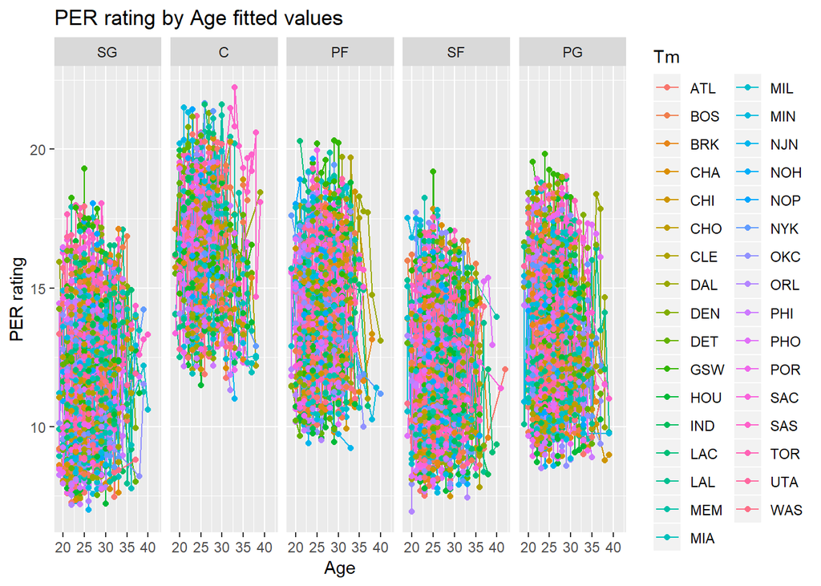

```r
ggplot(data=playerdata %>% filter(complete.cases(.)),aes(x=Age, y=mlrfit.r$fitted.values[,14])) + geom_line(aes(col=Tm))+
  geom_point(aes(col=Tm)) + facet_wrap(.~Pos, scales='fixed', nrow=1) +
  ggtitle("PER rating by Age fitted values")+ labs(y="PER rating", x="Age")
```

#### We can see from the final fitted values that for any position, the average player improves in their FT shooting ability as they get older (likely due to practice!)

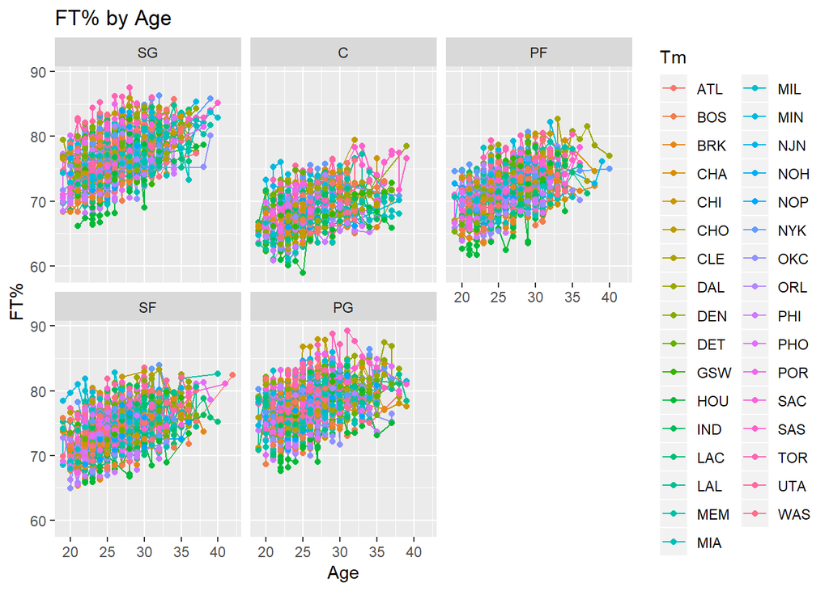

```r
ggplot(data=playerdata %>% filter(complete.cases(.)),aes(x=Age, y=mlrfit.r$fitted.values[,6])) + geom_line(aes(col=Tm))+
  geom_point(aes(col=Tm)) + facet_wrap(.~Pos, scales='fixed') +
  ggtitle("FT% by Age")+ labs(y="FT%", x="Age")
```

# Principal Component Analysis

#### We can look at the principal components to analyze the factors that cause the data to vary the most. We first center the data. Using the principal components from the centered data, we can see that 98% of the total variance can be explained by the first five principal components.

```r
#centering the data.
playerdata.av <- playerdata[,9:25] %>% filter(complete.cases(.)) %>% summarise_all(mean)
playerdata.centered <- playerdata[,9:25] %>% filter(complete.cases(.)) %>%
        sweep(MARGIN=2,
        apply(playerdata[,9:25] %>% filter(complete.cases(.)),2,mean)
        )

#principal components
player.pc <- prcomp(playerdata.centered)
player.pc
```

```
## Standard deviations (1, .., p=17):
##  [1] 352.8390264 131.5291195  89.5424532  69.8676355  52.8160763
##  [6]  33.8286461  21.1542282  16.8099138  15.8698134  14.9788069
## [11]  13.3986708  12.0477223   8.2662170   3.7686246   2.3053394
## [16]   0.6159045   0.0191266
##
## Rotation (n x k) = (17 x 17):
##                 PC1           PC2           PC3           PC4
## X3PA  -0.1889516245  0.7861336762 -0.4599414536  0.3134064256
## X3P.  -0.0018558796  0.0479196988 -0.0101374634  0.0229937778
## X2PA  -0.7782894282 -0.2457444482  0.2433692791  0.4093166068
## X2P.  -0.0055381454 -0.0084154351 -0.0153614119 -0.0133822276
## FTA   -0.3240433280  0.0123323010  0.0380208784  0.0934338705
## FT.   -0.0071735295  0.0290597110  0.0034480183  0.0298894938
## ORB   -0.1048489873 -0.2231901476 -0.2093971691 -0.1739595112
## DRB   -0.3366487533 -0.2170015651 -0.5947290948 -0.4831217144
## AST   -0.2692464076  0.4460296731  0.5072231064 -0.6325220064
## STL   -0.0743933951  0.0709994370 -0.0074719624 -0.0844970823
## BLK   -0.0488083991 -0.0898581960 -0.1150672519 -0.0780435922
## TOV   -0.1581598024  0.0959143485  0.0776828129 -0.1353876554
## PF    -0.1535284049 -0.0080164314 -0.2303604061 -0.1673118703
## PER   -0.0095458223 -0.0024219827  0.0007428736 -0.0027854198
## USG.  -0.0073106686  0.0026037418  0.0143116031  0.0239055631
## WS.48 -0.0001015859 -0.0000109852 -0.0001225495 -0.0001415066
## VORP  -0.0026767128  0.0014009977 -0.0012876940 -0.0044470242
##                 PC5           PC6           PC7           PC8          PC9
## X3PA   0.0785064886  4.967188e-02  0.1542502859  4.028532e-02 -0.009119793
## X3P.   0.0196793475  5.125036e-02 -0.1090484669 -2.946294e-02  0.030177193
## X2PA   0.3169237296  6.757535e-02  0.0007652047  5.335972e-03  0.020280382
## X2P.  -0.0032507190 -1.756340e-02  0.0262051490  2.263296e-02  0.031149912
## FTA   -0.9236199146 -1.215818e-01 -0.0252014318 -4.124123e-02  0.032365041
## FT.    0.0094268083  1.973210e-02 -0.0644237123 -9.315119e-03 -0.094375799
## ORB    0.0184467619 -2.331041e-01  0.8729202210 -1.362714e-01 -0.099293073
## DRB   -0.0060016262  4.376187e-01 -0.2285689263 -7.779430e-02 -0.033150431
## AST    0.0730404561  6.140616e-02  0.1032423163  3.747826e-02  0.030380752
## STL    0.0329904926 -1.595572e-01 -0.0461838707 -4.480340e-01  0.744872258
## BLK   -0.0143493552 -9.224444e-02  0.0776210927  8.582062e-01  0.456210899
## TOV   -0.0595420228 -1.267986e-01 -0.0701602051  1.738024e-01 -0.440895113
## PF     0.1697527656 -8.210879e-01 -0.3457750082 -2.858586e-02 -0.121060975
## PER   -0.0145727566  1.365817e-02  0.0344973971  1.336313e-02  0.025890548
```

[output cut: 24 more lines]

```
## X2PA   0.0038716857  1.610002e-03  1.441390e-05
## X2P.  -0.2027015846 -3.530829e-03  6.124609e-05
## FTA   -0.0083852079 -5.266626e-03  4.734604e-05
## FT.   -0.0343397364  9.330489e-04  2.584611e-04
## ORB   -0.0259441524 -4.275349e-03 -1.429494e-04
## DRB   -0.0028540924 -2.784180e-03 -3.218714e-05
## AST   -0.0163922978 -5.087415e-03 -6.010077e-05
## STL   -0.0237448540 -1.365787e-02 -2.877474e-04
## BLK   -0.0186205522 -1.098059e-02 -2.500833e-04
## TOV    0.0472745039  1.012093e-02 -1.042619e-04
## PF     0.0007763798  7.793394e-03  2.244402e-04
## PER    0.8048828919 -3.941994e-02  1.560142e-02
## USG.  -0.5496091751 -1.357602e-03 -7.249053e-03
## WS.48  0.0168561477  1.080189e-02 -9.997867e-01
## VORP   0.0288836513  9.988788e-01  1.140941e-02
```

```r
#we can also just use the default, which automatically centers the data
playerpca <- princomp(playerdata[,9:25])
#how many do we need?
csums <- cumsum(player.pc$sdev^2) / sum(player.pc$sdev^2)
csums
```

```
##  [1] 0.7768932 0.8848505 0.9348846 0.9653468 0.9827544 0.9898957 0.9926883
##  [8] 0.9944516 0.9960233 0.9974234 0.9985437 0.9994494 0.9998758 0.9999645
## [15] 0.9999976 1.0000000 1.0000000
```

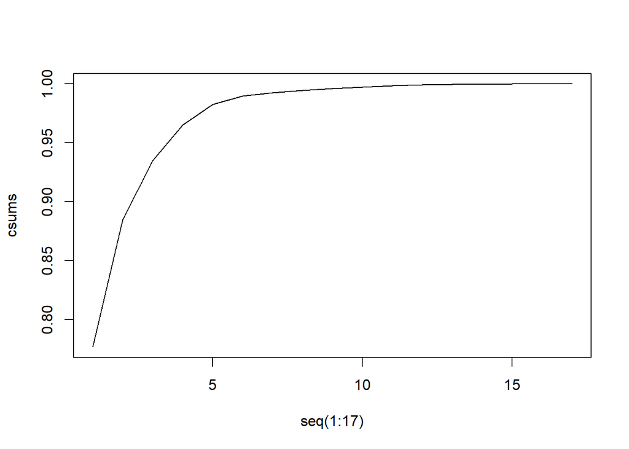

```r
plot(y=csums,x=seq(1:17), type='l')
```

```r
#is five enough?
PCs.proportion.variation.enuff(player.pc$sdev^2, q = 5, propn = 0.99,
                               nobs = length(playerdata$X3PA))
```

```
## [1] 1.359846e-107
```

#### We can also plot the transformed data for the first 2 PCs. We can see that these two PCs alone provide some ability to separate the players by their positions, although it is not perfect (position is not necessarily a clear classification).

```r
player.pc
```

```
## Standard deviations (1, .., p=17):
##  [1] 352.8390264 131.5291195  89.5424532  69.8676355  52.8160763
##  [6]  33.8286461  21.1542282  16.8099138  15.8698134  14.9788069
## [11]  13.3986708  12.0477223   8.2662170   3.7686246   2.3053394
## [16]   0.6159045   0.0191266
##
## Rotation (n x k) = (17 x 17):
##                 PC1           PC2           PC3           PC4
## X3PA  -0.1889516245  0.7861336762 -0.4599414536  0.3134064256
## X3P.  -0.0018558796  0.0479196988 -0.0101374634  0.0229937778
## X2PA  -0.7782894282 -0.2457444482  0.2433692791  0.4093166068
## X2P.  -0.0055381454 -0.0084154351 -0.0153614119 -0.0133822276
## FTA   -0.3240433280  0.0123323010  0.0380208784  0.0934338705
## FT.   -0.0071735295  0.0290597110  0.0034480183  0.0298894938
## ORB   -0.1048489873 -0.2231901476 -0.2093971691 -0.1739595112
## DRB   -0.3366487533 -0.2170015651 -0.5947290948 -0.4831217144
## AST   -0.2692464076  0.4460296731  0.5072231064 -0.6325220064
## STL   -0.0743933951  0.0709994370 -0.0074719624 -0.0844970823
## BLK   -0.0488083991 -0.0898581960 -0.1150672519 -0.0780435922
## TOV   -0.1581598024  0.0959143485  0.0776828129 -0.1353876554
## PF    -0.1535284049 -0.0080164314 -0.2303604061 -0.1673118703
## PER   -0.0095458223 -0.0024219827  0.0007428736 -0.0027854198
## USG.  -0.0073106686  0.0026037418  0.0143116031  0.0239055631
## WS.48 -0.0001015859 -0.0000109852 -0.0001225495 -0.0001415066
## VORP  -0.0026767128  0.0014009977 -0.0012876940 -0.0044470242
##                 PC5           PC6           PC7           PC8          PC9
## X3PA   0.0785064886  4.967188e-02  0.1542502859  4.028532e-02 -0.009119793
## X3P.   0.0196793475  5.125036e-02 -0.1090484669 -2.946294e-02  0.030177193
## X2PA   0.3169237296  6.757535e-02  0.0007652047  5.335972e-03  0.020280382
## X2P.  -0.0032507190 -1.756340e-02  0.0262051490  2.263296e-02  0.031149912
## FTA   -0.9236199146 -1.215818e-01 -0.0252014318 -4.124123e-02  0.032365041
## FT.    0.0094268083  1.973210e-02 -0.0644237123 -9.315119e-03 -0.094375799
## ORB    0.0184467619 -2.331041e-01  0.8729202210 -1.362714e-01 -0.099293073
## DRB   -0.0060016262  4.376187e-01 -0.2285689263 -7.779430e-02 -0.033150431
## AST    0.0730404561  6.140616e-02  0.1032423163  3.747826e-02  0.030380752
## STL    0.0329904926 -1.595572e-01 -0.0461838707 -4.480340e-01  0.744872258
## BLK   -0.0143493552 -9.224444e-02  0.0776210927  8.582062e-01  0.456210899
## TOV   -0.0595420228 -1.267986e-01 -0.0701602051  1.738024e-01 -0.440895113
## PF     0.1697527656 -8.210879e-01 -0.3457750082 -2.858586e-02 -0.121060975
## PER   -0.0145727566  1.365817e-02  0.0344973971  1.336313e-02  0.025890548
```

[output cut: 24 more lines]

```
## X2PA   0.0038716857  1.610002e-03  1.441390e-05
## X2P.  -0.2027015846 -3.530829e-03  6.124609e-05
## FTA   -0.0083852079 -5.266626e-03  4.734604e-05
## FT.   -0.0343397364  9.330489e-04  2.584611e-04
## ORB   -0.0259441524 -4.275349e-03 -1.429494e-04
## DRB   -0.0028540924 -2.784180e-03 -3.218714e-05
## AST   -0.0163922978 -5.087415e-03 -6.010077e-05
## STL   -0.0237448540 -1.365787e-02 -2.877474e-04
## BLK   -0.0186205522 -1.098059e-02 -2.500833e-04
## TOV    0.0472745039  1.012093e-02 -1.042619e-04
## PF     0.0007763798  7.793394e-03  2.244402e-04
## PER    0.8048828919 -3.941994e-02  1.560142e-02
## USG.  -0.5496091751 -1.357602e-03 -7.249053e-03
## WS.48  0.0168561477  1.080189e-02 -9.997867e-01
## VORP   0.0288836513  9.988788e-01  1.140941e-02
```

```r
#what do the first 5 PCs represent?
addback <- playerdata.av %>% matrix(ncol=length(playerdata.av), nrow=nrow(playerdata.centered), byrow=T) %>%
  unlist() %>% matrix(ncol=length(playerdata.av), nrow=nrow(playerdata.centered), byrow=F)

plpc.rot <- data.frame(Pos=(playerdata %>% filter(complete.cases(.)))$Pos,
                       ((player.pc$x %>% as.matrix) + addback) %*% player.pc$rotation[,1:5])
plpc.rot %>% group_by(Pos) %>% summarise_all(median)
```

```
## # A tibble: 5 x 6
##   Pos     PC1   PC2    PC3   PC4   PC5
##   <fct> <dbl> <dbl>  <dbl> <dbl> <dbl>
## 1 SG    -437. 152.  -107.   24.0  38.5
## 2 C     -380.  16.7  -49.1 -43.0  14.1
## 3 PF    -390.  98.3  -86.5 -10.2  12.6
## 4 SF    -414. 164.  -116.   21.9  34.5
## 5 PG    -488. 111.   -82.3  46.4  52.5
```

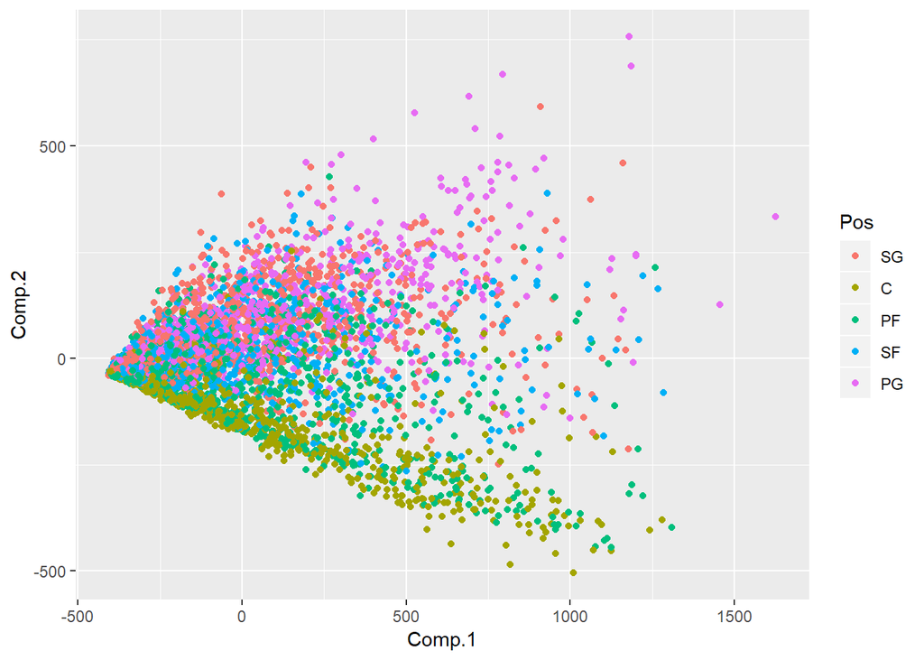

```r
#looking only at the first two PCs
#Use predict() to get scores

#pl1 <- ((player.pc$x %>% as.matrix) + addback) %*% player.pc$rotation[,1]
#pl2 <- ((player.pc$x %>% as.matrix) + addback) %*% player.pc$rotation[,2]
#pl.tr <- data.frame(Pos=(playerdata %>% filter(complete.cases(.)))$Pos, year=(playerdata %>% filter(complete.cases(.)))$year,
 #                   pc1=pl1, pc2=pl2)
#ggplot(pl.tr) + geom_point(aes(x=pc1,y=pc2, col=Pos))

#pl.tr <- pl.tr %>% filter(Pos%in% c("PG","C"))
#ggplot(pl.tr) + geom_point(aes(x=pc1,y=pc2, col=Pos))

plpca <- predict(playerpca) %>% data.frame(Pos=playerdata$Pos)
ggplot(plpca) + geom_point(aes(x=Comp.1, y=Comp.2, col=Pos))
```

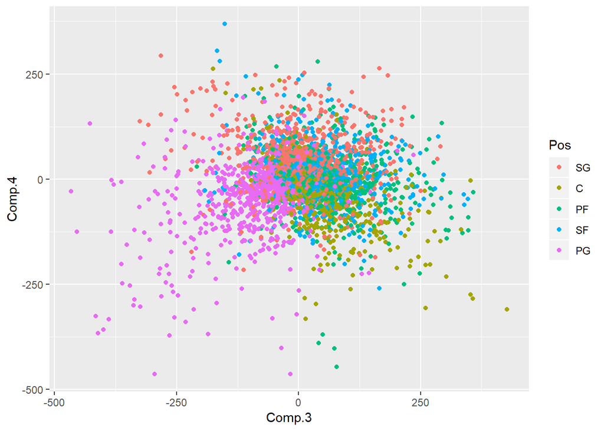

```r
ggplot(plpca) + geom_point(aes(x=Comp.3, y=Comp.4, col=Pos))
```

# Factor Analysis

#### We can also perform Factor analysis to look at factors that explain the data best. I use 3 factors, which is enough to explain 65.8% of the total variance of the data. Looking at the three factors, we see similar interpretations as the PCs. The first factor places large weights on all of the contributors to overall ability. The second factor places larger weights on rebounding/blocks and 2P shots, indicating heavier weights for players who play close to the goal (SF/PF/C). The third factor places much larger weights on 3P shots, assists, and steals, indicating heavier loadings for players who play away from the goal (PG/SG).

#### The plots show similar results, we can use the factors to discern the differences in position.

```r
playerfact <- factanal(x = playerdata[,9:25], factors = 3, scores = "regression", rotation = "varimax",     method = "mle")
playerfact
```

```
##
## Call:
## factanal(x = playerdata[, 9:25], factors = 3, scores = "regression",     rotation = "varimax", method = "mle")
##
## Uniquenesses:
##  X3PA  X3P.  X2PA  X2P.   FTA   FT.   ORB   DRB   AST   STL   BLK   TOV
## 0.563 0.859 0.143 0.705 0.186 0.866 0.107 0.111 0.160 0.284 0.307 0.033
##    PF   PER  USG. WS.48  VORP
## 0.224 0.005 0.625 0.239 0.394
##
## Loadings:
##       Factor1 Factor2 Factor3
## X3PA   0.488           0.443
## X3P.                   0.374
## X2PA   0.853   0.342   0.114
## X2P.           0.535
## FTA    0.808   0.345   0.204
## FT.            0.115   0.338
## ORB    0.634   0.497  -0.494
## DRB    0.820   0.413  -0.215
## AST    0.727           0.557
## STL    0.793   0.141   0.258
## BLK    0.572   0.444  -0.411
## TOV    0.912   0.161   0.332
## PF     0.838   0.238  -0.129
## PER    0.365   0.870   0.323
## USG.   0.325   0.280   0.437
## WS.48  0.228   0.819   0.195
## VORP   0.633   0.410   0.192
##
##                Factor1 Factor2 Factor3
## SS loadings      6.418   2.931   1.840
## Proportion Var   0.378   0.172   0.108
## Cumulative Var   0.378   0.550   0.658
##
## Test of the hypothesis that 3 factors are sufficient.
## The chi square statistic is 17021.64 on 88 degrees of freedom.
## The p-value is 0
```

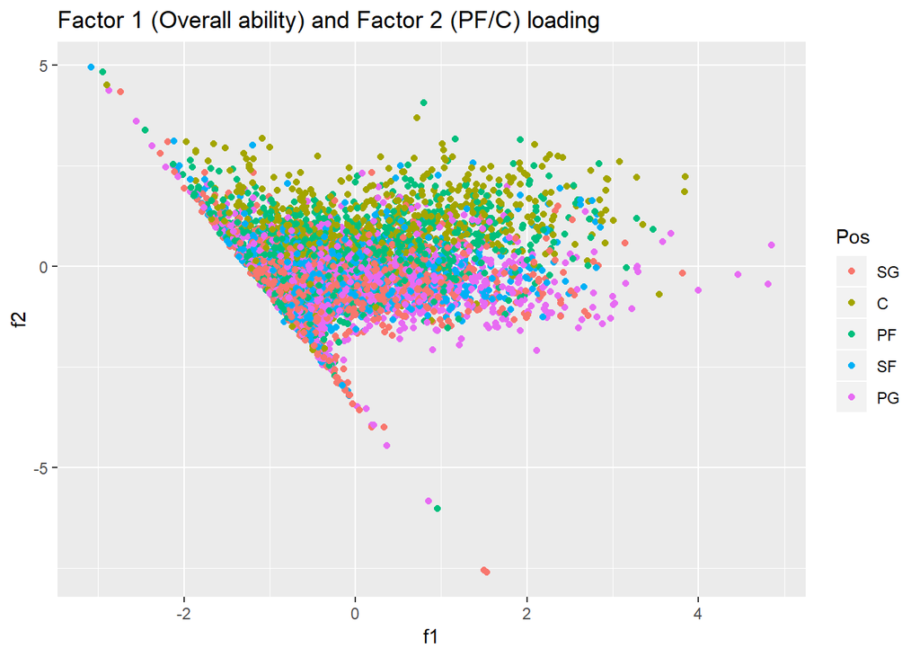

```r
#plotting the factor scores
data.frame(Pos=playerdata$Pos,f1=playerfact$scores[,1], f2=playerfact$scores[,2]) %>%
  ggplot() + geom_point(aes(x=f1,y=f2,col=Pos)) + ggtitle("Factor 1 (Overall ability) and Factor 2 (PF/C) loading")
```

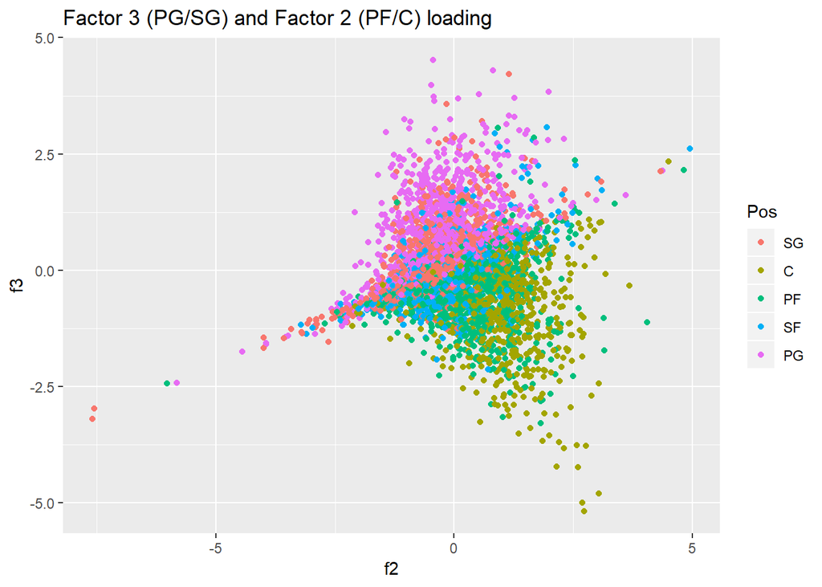

```r
data.frame(Pos=playerdata$Pos,f2=playerfact$scores[,2], f3=playerfact$scores[,3]) %>%
  ggplot() + geom_point(aes(x=f2,y=f3,col=Pos)) + ggtitle("Factor 3 (PG/SG) and Factor 2 (PF/C) loading")
```

# Classification

#### Now we can try to classify players to their position based on their statistics. We use both linear and quadratic discriminant analysis methods. We have five different positions (classes), so testing for equality of all five covariance matrices is a likely going to reject that hypothesis for at least one case. Instead, we use both LDA and QDA and compare their performances. The two methods have very similar apparent rates of misclassification, 43.2% and 43.7% respectively. Because we prefer a simpler model and it performs slightly better in LOOCV, we prefer LDA in this case. We can see that the two methods predict different classes for 28% of the observations, which is quite significant and indicates that we would have a noticeable difference if we used the other model, even if the actual error rates are similar. The primary issues in our classification seems to be mis-classifying a SF as either PF (power forward) or SG (shooting guard), which makes sense because many players will switch between these positions depending on the situation. We also see some difficulty in classifying C (center) and PF (power forward), two closely-related positions as well. Overall, the apparent error rate is quite high and provides more evidence that “Position” is a more fluid variable than we might believe, especially in the modern NBA.

```r
library(MASS)
#cv for lda and qda
linda <- lda(Pos~as.matrix(playerdata[,9:25]), data=playerdata,method='mle', CV=TRUE)
quada <- qda(Pos~as.matrix(playerdata[,9:25]), data=playerdata, method='mle', CV=TRUE)

#How do the two methods compare in predictions?
#lda does very slightly better
#main issue seems to be misclassifying SFs as SGs or PFs and PFs/Cs getting mixed up
table(playerdata$Pos, linda$class)
```

```
##
##       SG   C  PF  SF  PG
##   SG 702   2  31 252 130
##   C   32 366 179  40   2
##   PF 107 157 405 206  17
##   SF 322  11  94 490  36
##   PG 295   2  15  68 656
```

```r
table(playerdata$Pos, quada$class)
```

```
##
##       SG   C  PF  SF  PG
##   SG 768   6  29 172 142
##   C   43 387 142  43   4
##   PF 127 171 344 235  15
##   SF 374  17  86 443  33
##   PG 328  10   9  33 656
```

```r
mean(playerdata$Pos != linda$class)
```

```
## [1] 0.4327485
```

```r
mean(playerdata$Pos != quada$class)
```

```
## [1] 0.4372969
```

```r
#Do the two methods predict approximately the same classification for each observation?
#28% difference (seems like a lot)
table(linda$class, quada$class)
```

```
##
##        SG    C   PF   SF   PG
##   SG 1165    7   26  148  112
##   C     0  428  109    1    0
##   PF   49  130  391  143   11
##   SF  302   24   70  621   39
##   PG  124    2   14   13  688
```

```r
mean(linda$class != quada$class)
```

```
## [1] 0.2867663
```

# Conclusion

#### We have performed five different analyses on the NBA player data. In the MANOVA analysis, we found statistically significant evidence (via the Wilks statistic) that both Position and Team are important factors in explaining the variation in our 17 different player statistics that we collected. In the multivariate linear regression analysis we found a similar result, however many of the regression coefficients for teams are not significantly non-zero (even with large sample size). Even though we included many insignificant terms in our model, we still found that the full model fit the data better than other reduced models via Likelihood ratio test. We also found that minutes played (MP) and age had a significant positive relationship with all of the variables.

#### Looking at dimension reduction techniques, we found in both PCA and Factor analysis that much of the variation in the data can be explained by a few (<5) factors. These factors/principal components can be best interpreted as measures of overall ability, contrast between guards and forwards, contrasts between inside and outside players, and contrasts between high scorers vs. role players/defenders/rebounders. While using this data to try and classify players to their positions, we found it difficult because of the similarities in the data between SFs and their closely related positions of SG and PF, and thus there may be other, better ways to classify players beyond just position.

#### One key assumption underlying most of these models is that our variables follow a multivariate normal distribution, which is likely not the case based on our visual analysis of quantile plots. However, we should note that our sample size is quite large and thus our results are likely robust to departures from this assumption.